# 🧔 - volunteer, please

# 👩‍🔬 - volunteer, please

# Data Visualizations are Cool

## By Patrick Dudas

why?

## 🧔 - Let's look at some data.

```python
data
```

|  | dataset | x | y |
| --- | --- | --- | --- |
| 0 | A | 55.384600 | 97.179500 |
| 1 | A | 51.538500 | 96.025600 |
| 2 | A | 46.153800 | 94.487200 |
| 3 | A | 42.820500 | 91.410300 |
| 4 | A | 40.769200 | 88.333300 |
| ... | ... | ... | ... |
| 1841 | M | 33.674442 | 26.090490 |
| 1842 | M | 75.627255 | 37.128752 |
| 1843 | M | 40.610125 | 89.136240 |
| 1844 | M | 39.114366 | 96.481751 |
| 1845 | M | 34.583829 | 89.588902 |

1846 rows × 3 columns

# 🧔 - Wow, that's a lot of data.

## 🧔 - Let's see if we can figure anything out with this data.

## 🧔 - How many data sets are there?

```python
len(data['dataset'].unique())
```

```
13
```

### And they are...

```python
data['dataset'].unique()
```

```
array(['A', 'B', 'C', 'D', 'E', 'F', 'G', 'H', 'I', 'J', 'K', 'L', 'M'],
      dtype=object)
```

## 🧔 - Wow, that's a lot of data sets.

## 🧔 - Let's calculate the mean values for the *x* values.

```python
data.groupby('dataset')["x"].mean()
```

```
dataset
A    54.263273
B    54.266100
C    54.261442
D    54.269927
E    54.260150
F    54.267341
G    54.268805
H    54.260303
I    54.267320
J    54.268730
K    54.265882
L    54.267849
M    54.266916
Name: x, dtype: float64
```

## 🧔 - Hmmm... 🤔

## 🧔 - They are all roughly the same!

## 🧔 - Let's calculate the mean values for the *y* values.

```python
data.groupby('dataset')["y"].mean()
```

```
dataset
A    47.832253
B    47.834721
C    47.830252
D    47.836988
E    47.839717
F    47.839545
G    47.835450
H    47.839829
I    47.837717
J    47.830823
K    47.831496
L    47.835896
M    47.831602
Name: y, dtype: float64
```

## 🧔 - Hmmm... 🤔

## 🧔 - They are all roughly the same!

## 🧔 - Let's calculate the mean and sd values for both the *x* and *y* values.

```python
d = {}
d['mean x'] = data.groupby('dataset')["x"].mean().tolist()
d['mean y'] = data.groupby('dataset')["y"].mean().tolist()
d['sd x'] = data.groupby('dataset')["x"].std().tolist()
d['sd y'] = data.groupby('dataset')["y"].std().tolist()
df = pd.DataFrame(data=d)
df.index.name = "data sets"
df
```

| data sets | mean x | mean y | sd x | sd y |
| --- | --- | --- | --- | --- |
| 0 | 54.263273 | 47.832253 | 16.765142 | 26.935403 |
| 1 | 54.266100 | 47.834721 | 16.769825 | 26.939743 |
| 2 | 54.261442 | 47.830252 | 16.765898 | 26.939876 |
| 3 | 54.269927 | 47.836988 | 16.769959 | 26.937684 |
| 4 | 54.260150 | 47.839717 | 16.769958 | 26.930002 |
| 5 | 54.267341 | 47.839545 | 16.768959 | 26.930275 |
| 6 | 54.268805 | 47.835450 | 16.766704 | 26.939998 |
| 7 | 54.260303 | 47.839829 | 16.767735 | 26.930192 |
| 8 | 54.267320 | 47.837717 | 16.760013 | 26.930036 |
| 9 | 54.268730 | 47.830823 | 16.769239 | 26.935727 |
| 10 | 54.265882 | 47.831496 | 16.768853 | 26.938608 |
| 11 | 54.267849 | 47.835896 | 16.766759 | 26.936105 |
| 12 | 54.266916 | 47.831602 | 16.770000 | 26.937902 |

## 🧔 - 😲 They are all roughly the same! 😲

## 🧔 - In conclusion, these data sets must all be the same!

## 🧔 - ✨ Thanks for coming to my TED talk! ✨

## 🧔 - Have a great day! 😃

## 👩‍🔬 - Wait..

## 🧔 - yes?

## 👩‍🔬 - have you looked at the data?

## 🧔 - why?

## 👩‍🔬 - sometimes statistics don't tell the whole story. Convert the data into another format and see if these trends continue.

## 🧔 - fine...

## 👩‍🔬 - Let's try sound, this is call 💥sonification💥

```python
sr = 22050
T = .1
t = np.linspace(0, T, int(T*sr), endpoint=False)
x = data[data['dataset'] == "A"]["x"].multiply(10).sample(n=100, random_state=1).tolist()
e = []
for a in x:
    e.append(0.5*np.sin(2*np.pi*a*t))
sound1 = np.array(e)
ipd.Audio(sound1.flatten(), rate=sr)
```

[interactive chart not shown]

```python
sr = 22050
T = .1
t = np.linspace(0, T, int(T*sr), endpoint=False)
x = data[data['dataset'] == "B"]["x"].multiply(10).sample(n=100, random_state=1).tolist()
e = []
for a in x:
    e.append(0.5*np.sin(2*np.pi*a*t))
sound2 = np.array(e)
ipd.Audio(sound2.flatten(), rate=sr)
```

[interactive chart not shown]

## 🧔 - WOW! This sound is *banging*. I am going to sample this for my rave band.

## 👩‍🔬 - you're not in a band

# 😎 - yes I am

## 👩‍🔬 - ...

## 🧔 - ...

## 🧔 - WOW! You can hear a difference! I wish I could see the sound!

## 👩‍🔬 - You can! Remember, visualizations are just representations of signals. See...

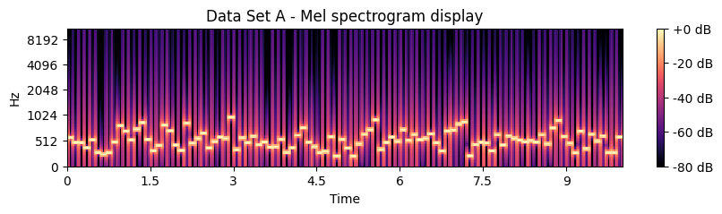

```python
fig
```

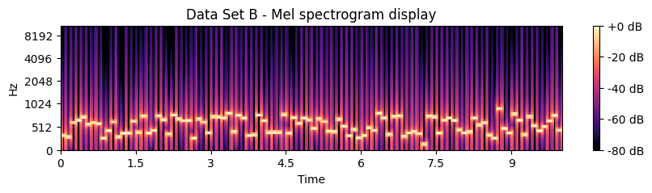

```python
fig
```

## 🧔 - oww, that's pretty...

## 👩‍🔬 - This is one of the big "gotchas" of data visualizations. It is part data and part art.

## 🧔 - why is this a "gotcha"?

## 👩‍🔬 - because art is subjective. It is a bit of a balancing act between "What looks cool!" and "What looks precise."

## 🧔 - so how do I build one of these visualatrons?

## 👩‍🔬 - visualizations. Well, there are two factors to consider when building visualatrons, I mean visualization. They are the *spatial or planar encoding* and the *visual or retinal encoding*. For now, we will call them spatial and visual encodings. Let's start with the visual encodings.

```python
%%html
<input type="button" onclick="gShow1()" value="50 random points">
<input type="button" onclick="gEncode1()" value="Encode by Size">
<div id="graph1"></div>
<script type="module">
    import * as d3 from "https://cdn.skypack.dev/d3@6";
    function getRandom(arr, n) {
        var result = new Array(n),
        len = arr.length,
        taken = new Array(len);

        while (n--) {
            var x = Math.floor(Math.random() * len);
            result[n] = arr[x in taken ? taken[x] : x];
            taken[x] = --len in taken ? taken[len] : len;
        }
        return result;
    }
    d3.csv("https://gist.githubusercontent.com/dudaspm/ea7f4e372f7cc4b37b9e1105842eb587/raw/d2e553c0f343289d5d57e0345425c496b7ee49c1/dataset.csv")
        .then(function(data){
            var width = 770
            var height = 100
            var margin = 10
            var data = data.filter((d,i)=>d.dataset == "A")
            data = data.map(d=> ({"dataset":d.dataset,"x":+d.x,"y":+d.y}))
            data = getRandom(data,50)
            window.x1 = d3.scaleLinear().range([margin,width-margin]).domain(d3.extent(data,(d,i)=>i))
            window.size = d3.scaleLinear().range([1,10]).domain(d3.extent(data,(d,i)=>d.x))
            var svg = d3.select("div#graph1").append("svg")
                .attr("width", width)
                .attr("height", height)

            svg.selectAll("circle")
                .data(data)
                .join("circle")
                .attr("cx", d=>-10)
                .attr("cy", d => height/2)
                .attr("r", 5)
                .style("stroke", "darkgrey" )
                .style("stroke-width", 1)
                .style("fill", "steelblue")

        })
        .catch(function(error){
            console.log(error)
        })
    window.gShow1 = function() {
        var width = 770
        var height = 100
        d3.select("div#graph1").select("svg").selectAll("circle")
            .attr("cx", d=>(Math.floor(Math.random() * 2)) ? -Math.floor(Math.random() * 100) : width+Math.floor(Math.random() * 100))
            .attr("cy", d=>(Math.floor(Math.random() * 2)) ? -Math.floor(Math.random() * 100) : height+Math.floor(Math.random() * 100))
            .transition()
            .duration(1000)
            .delay((d,i)=>i*50)
            .attr("cx", (d,i) => x1(i))
            .attr("cy", d => height/2)
    }
    window.gEncode1 = function() {
        d3.select("div#graph1").select("svg").selectAll("circle")
            .transition()
            .duration(1000)
            .delay((d,i)=>i*50)
            .attr("r", (d,i) => size(d.x))
    }
</script>
```

## 🧔 - ohhh

```python
%%html
<input type="button" onclick="gShow2()" value="50 random points">
<input type="button" onclick="gEncode2()" value="Encode by Color">
<div id="graph2"></div>
<script type="module">
    import * as d3 from "https://cdn.skypack.dev/d3@6";
    function getRandom(arr, n) {
        var result = new Array(n),
        len = arr.length,
        taken = new Array(len);

        while (n--) {
            var x = Math.floor(Math.random() * len);
            result[n] = arr[x in taken ? taken[x] : x];
            taken[x] = --len in taken ? taken[len] : len;
        }
        return result;
    }
    d3.csv("https://gist.githubusercontent.com/dudaspm/ea7f4e372f7cc4b37b9e1105842eb587/raw/d2e553c0f343289d5d57e0345425c496b7ee49c1/dataset.csv")
        .then(function(data){
            var width = 770
            var height = 100
            var margin = 10
            var data = data.filter((d,i)=>d.dataset == "A")
            data = data.map(d=> ({"dataset":d.dataset,"x":+d.x,"y":+d.y}))
            data = getRandom(data,50)
            window.x2 = d3.scaleLinear().range([margin,width-margin]).domain(d3.extent(data,(d,i)=>i))
            window.color = d3.scaleLinear().range([0,1]).domain(d3.extent(data,(d,i)=>d.x))
            window.palette = d3.interpolateViridis
            var svg = d3.select("div#graph2").append("svg")
                .attr("width", width)
                .attr("height", height)

            svg.selectAll("circle")
                .data(data)
                .join("circle")
                .attr("cx", d=>-10)
                .attr("cy", d => height/2)
                .attr("r", 5)
                .style("stroke", "darkgrey" )
                .style("stroke-width", 1)
                .style("fill", "steelblue")

        })
        .catch(function(error){
            console.log(error)
        })
    window.gShow2 = function() {
        var width = 770
        var height = 100
        d3.select("div#graph2").select("svg").selectAll("circle")
            .attr("cx", d=>(Math.floor(Math.random() * 2)) ? -Math.floor(Math.random() * 100) : width+Math.floor(Math.random() * 100))
            .attr("cy", d=>(Math.floor(Math.random() * 2)) ? -Math.floor(Math.random() * 100) : height+Math.floor(Math.random() * 100))
            .transition()
            .duration(1000)
            .delay((d,i)=>i*50)
            .attr("cx", (d,i) => x2(i))
            .attr("cy", d => height/2)
    }
    window.gEncode2 = function() {
        d3.select("div#graph2").select("svg").selectAll("circle")
            .transition()
            .duration(1000)
            .delay((d,i)=>i*50)
            .style("fill", (d,i) => palette(color(d.x)))
    }
</script>
```

## 🧔 - ahhh

```python
%%html
<input type="button" onclick="gShow3()" value="50 random points">
<input type="button" onclick="gEncode3()" value="Encode by Emoji">
<div id="graph3"></div>
<script type="module">
    import * as d3 from "https://cdn.skypack.dev/d3@6";
    function getRandom(arr, n) {
        var result = new Array(n),
        len = arr.length,
        taken = new Array(len);

        while (n--) {
            var x = Math.floor(Math.random() * len);
            result[n] = arr[x in taken ? taken[x] : x];
            taken[x] = --len in taken ? taken[len] : len;
        }
        return result;
    }
    d3.csv("https://gist.githubusercontent.com/dudaspm/ea7f4e372f7cc4b37b9e1105842eb587/raw/d2e553c0f343289d5d57e0345425c496b7ee49c1/dataset.csv")
        .then(function(data){
            var width = 770
            var height = 100
            var margin = 20
            var data = data.filter((d,i)=>d.dataset == "A")
            data = data.map(d=> ({"dataset":d.dataset,"x":+d.x,"y":+d.y}))
            data = getRandom(data,50)
            window.x3 = d3.scaleLinear().range([margin,width-margin]).domain(d3.extent(data,(d,i)=>i))
            window.glyphs = d3.scaleLinear().range([0,19]).domain(d3.extent(data,(d,i)=>d.x))
            var svg = d3.select("div#graph3").append("svg")
                .attr("width", width)
                .attr("height", height)

            svg.selectAll("text")
                .data(data)
                .join("text")
                .attr("x", d=>-10)
                .attr("y", d => height/2)
                .text("O")

        })
        .catch(function(error){
            console.log(error)
        })
    window.gShow3 = function() {
        var width = 770
        var height = 100

        d3.select("div#graph3").select("svg").selectAll("text")
            .attr("x", (d,i) => x3(i))
            .attr("y", d => height/2)
    }
    window.gEncode3 = function() {
        var soup = '🐈,🐦,🐳,🐧,🐕,🐙,🐝,🐄,🐪,🐍,🐞,🐬,🐑,🐉,🐤,🐢,🐒,🐘,🐠,🐁'.split(',');
        d3.select("div#graph3").select("svg").selectAll("text")
            .transition()
            .duration(1000)
            .delay((d,i)=>i*50)
            .text(d=>soup[Math.floor(glyphs(d.x))])
    }
</script>
```

## 🧔 - whhhat?

## 👩‍🔬 - When you translate signals to symbols, we call these symbols glyphs and the process of connecting glyphs with data, 💥semiotics💥

## 🧔 - Can you encode multiple things with objects?

## 👩‍🔬 - Yep, but we need to ask, are the data integral or separable? Let's look at an example.

# 👩‍🔬 - Let's map our x and y values two different ways and see if we can pick how best to map our values.

```python
%%html
<input type="button" onclick="gShow4()" value="50 random points">
<input type="button" onclick="gEncode4()" value="Encode by Width and Height">
<div id="graph4"></div>
<script type="module">
    import * as d3 from "https://cdn.skypack.dev/d3@6";
    function getRandom(arr, n) {
        var result = new Array(n),
        len = arr.length,
        taken = new Array(len);

        while (n--) {
            var x = Math.floor(Math.random() * len);
            result[n] = arr[x in taken ? taken[x] : x];
            taken[x] = --len in taken ? taken[len] : len;
        }
        return result;
    }
    d3.csv("https://gist.githubusercontent.com/dudaspm/ea7f4e372f7cc4b37b9e1105842eb587/raw/d2e553c0f343289d5d57e0345425c496b7ee49c1/dataset.csv")
        .then(function(data){
            var width = 770
            var height = 100
            var margin = 10
            var data = data.filter((d,i)=>d.dataset == "A")
            data = data.map(d=> ({"dataset":d.dataset,"x":+d.x,"y":+d.y}))
            window.x4 = d3.scaleLinear().range([margin,width-margin]).domain(d3.extent(data,(d,i)=>i))
            window.elw = d3.scaleLinear().range([1,10]).domain(d3.extent(data,(d,i)=>d.x))
            window.elh = d3.scaleLinear().range([1,10]).domain(d3.extent(data,(d,i)=>d.y))
            var svg = d3.select("div#graph4").append("svg")
                .attr("width", width)
                .attr("height", height)

            svg.selectAll("ellipse")
                .data(data)
                .join("ellipse")
                .attr("cx", d=>-10)
                .attr("cy", d => height/2)
                .attr("rx", 5)
                .attr("ry", 5)
                .style("stroke", "darkgrey" )
                .style("stroke-width", 1)
                .style("fill", "steelblue")

        })
        .catch(function(error){
            console.log(error)
        })
    window.gShow4 = function() {
        var width = 770
        var height = 100
        d3.select("div#graph4").select("svg").selectAll("ellipse")
            .attr("cx", d=>(Math.floor(Math.random() * 2)) ? -Math.floor(Math.random() * 100) : width+Math.floor(Math.random() * 100))
            .attr("cy", d=>(Math.floor(Math.random() * 2)) ? -Math.floor(Math.random() * 100) : height+Math.floor(Math.random() * 100))
            .transition()
            .duration(1000)
            .delay((d,i)=>i*20)
            .attr("cx", (d,i) => x4(i))
            .attr("cy", d => height/2)
    }
    window.gEncode4 = function() {
        d3.select("div#graph4").select("svg").selectAll("ellipse")
            .transition()
            .duration(1000)
            .delay((d,i)=>i*20)
            .attr("rx", (d,i) => elw(d.x))
            .attr("ry", (d,i) => elh(d.y))
    }
</script>
```

```python
%%html
<input type="button" onclick="gShow5()" value="50 random points">
<input type="button" onclick="gEncode5()" value="Encode by Color and Height">
<div id="graph5"></div>
<script type="module">
    import * as d3 from "https://cdn.skypack.dev/d3@6";
    d3.csv("https://gist.githubusercontent.com/dudaspm/ea7f4e372f7cc4b37b9e1105842eb587/raw/d2e553c0f343289d5d57e0345425c496b7ee49c1/dataset.csv")
        .then(function(data){
            var width = 770
            var height = 100
            var margin = 10
            var data = data.filter((d,i)=>d.dataset == "A")
            data = data.map(d=> ({"dataset":d.dataset,"x":+d.x,"y":+d.y}))
            window.x5 = d3.scaleLinear().range([margin,width-margin]).domain(d3.extent(data,(d,i)=>i))
            window.ecolor = d3.scaleLinear().range([0,1]).domain(d3.extent(data,(d,i)=>d.x))
            window.elh = d3.scaleLinear().range([1,10]).domain(d3.extent(data,(d,i)=>d.y))
            window.palette = d3.interpolateViridis
            var svg = d3.select("div#graph5").append("svg")
                .attr("width", width)
                .attr("height", height)

            svg.selectAll("ellipse")
                .data(data)
                .join("ellipse")
                .attr("cx", d=>-10)
                .attr("cy", d => height/2)
                .attr("rx", 5)
                .attr("ry", 5)
                .style("stroke", "darkgrey" )
                .style("stroke-width", 1)
                .style("fill", "steelblue")

        })
        .catch(function(error){
            console.log(error)
        })
    window.gShow5 = function() {
        var width = 770
        var height = 100
        d3.select("div#graph5").select("svg").selectAll("ellipse")
            .attr("cx", d=>(Math.floor(Math.random() * 2)) ? -Math.floor(Math.random() * 100) : width+Math.floor(Math.random() * 100))
            .attr("cy", d=>(Math.floor(Math.random() * 2)) ? -Math.floor(Math.random() * 100) : height+Math.floor(Math.random() * 100))
            .transition()
            .duration(1000)
            .delay((d,i)=>i*20)
            .attr("cx", (d,i) => x5(i))
            .attr("cy", d => height/2)
    }
    window.gEncode5 = function() {
        d3.select("div#graph5").select("svg").selectAll("ellipse")
            .transition()
            .duration(1000)
            .delay((d,i)=>i*20)
            .attr("ry", (d,i) => elh(d.y))
            .style("fill", (d,i) => palette(ecolor(d.x)))
    }
</script>
```

## 🧔 - I think I am starting to get it. I have an idea! Let's check out all the datasets based on these visual encodings.

```python
%%html
<input type="button" onclick="gShow6()" value="All the DATA">
<input type="button" onclick="gEncode6()" value="Encode by Width and Height">
<div id="graph6"></div>
<script type="module">
    import * as d3 from "https://cdn.skypack.dev/d3@6";
    d3.csv("https://gist.githubusercontent.com/dudaspm/ea7f4e372f7cc4b37b9e1105842eb587/raw/d2e553c0f343289d5d57e0345425c496b7ee49c1/dataset.csv")
        .then(function(data){
            var width = 770
            var height = 600
            var margin = 10
            data = data.map(d=> ({"dataset":d.dataset,"x":+d.x,"y":+d.y}))
            window.x6 = d3.scaleLinear().range([margin,width-margin]).domain(d3.extent(data.filter((d,i)=>d.dataset == "A"),(d,i)=>i))
            window.y6 = d3.scaleBand().range([margin,height-margin]).domain(["0","A","B","C","D","E","F","G","H","I","J","K","L","M","N"])
            console.log(d3.range(13))
            window.larray = data.filter((d,i)=>d.dataset == "A").length
            window.elw2 = d3.scaleLinear().range([1,10]).domain(d3.extent(data,(d,i)=>d.x))
            window.elh2 = d3.scaleLinear().range([1,10]).domain(d3.extent(data,(d,i)=>d.y))
            var svg = d3.select("div#graph6").append("svg")
                .attr("width", width)
                .attr("height", height)

            svg.selectAll("ellipse")
                .data(data)
                .join("ellipse")
                .attr("cx", d=>(Math.floor(Math.random() * 2)) ? -Math.floor(Math.random() * 100) : width+Math.floor(Math.random() * 100))
                .attr("cy", d=>(Math.floor(Math.random() * 2)) ? -Math.floor(Math.random() * 100) : height+Math.floor(Math.random() * 100))
                .attr("rx", 5)
                .attr("ry", 5)
                .style("stroke", "darkgrey" )
                .style("stroke-width", 1)
                .style("fill", "steelblue")

        })
        .catch(function(error){
            console.log(error)
        })
    window.gShow6 = function() {
        var width = 770
        var height = 600

        console.log(larray)
        d3.select("div#graph6").select("svg").selectAll("ellipse")
            .attr("cx", d=>(Math.floor(Math.random() * 2)) ? -Math.floor(Math.random() * 100) : width+Math.floor(Math.random() * 100))
            .attr("cy", d=>(Math.floor(Math.random() * 2)) ? -Math.floor(Math.random() * 100) : height+Math.floor(Math.random() * 100))
            .transition()
            .duration(1000)
            .delay((d,i)=>i*5)
            .attr("cx", (d,i) => x6(Math.floor(i%larray)))
            .attr("cy", d => y6(d.dataset))
    }
    window.gEncode6 = function() {
        d3.select("div#graph6").select("svg").selectAll("ellipse")
            .transition()
            .duration(1000)
            .delay((d,i)=>i*5)
            .attr("rx", (d,i) => elw(d.x))
            .attr("ry", (d,i) => elh(d.y))
    }
</script>
```

### 🧔 - There is definitely something going on with these datasets. But I am still not convinced that some are the same.

### 👩‍🔬 - Good call, maybe we should discuss the last component of visualizations...

### 🧔 - tacos?

### 👩‍🔬 - I thought we were finally having a breakthrough. No, the spatial component. This is the most important component of them all. It's like the old saying...

### 🧔 - you are what you eat?

### 👩‍🔬 - You're hungry, aren't you.

### 🧔 - yes.

### 👩‍🔬 - Well, the saying is... location, location, location.

## 👩‍🔬 - The spatial component is all about using space to code data. Let's take a look at two plots.

```python
%%html
<h4> Data Set 1 </h2>
<input type="radio" name="graph1" onclick="graph1('A')" disabled> Forbidden
<input type="radio" name="graph1" onclick="graph1('B')"> B
<input type="radio" name="graph1" onclick="graph1('C')"> C
<input type="radio" name="graph1" onclick="graph1('D')"> D
<input type="radio" name="graph1" onclick="graph1('E')"> E
<input type="radio" name="graph1" onclick="graph('F')"> F
<input type="radio" name="graph1" onclick="graph1('G')" checked> G
<input type="radio" name="graph1" onclick="graph1('H')"> H
<input type="radio" name="graph1" onclick="graph1('I')"> I
<input type="radio" name="graph1" onclick="graph1('J')"> J
<input type="radio" name="graph1" onclick="graph1('K')"> K
<input type="radio" name="graph1" onclick="graph1('L')"> L
<input type="radio" name="graph1" onclick="graph1('M')"> M

<h4> Data Set 2 </h2>
<input type="radio" name="graph2" onclick="graph2('A')" disabled> Forbidden
<input type="radio" name="graph2" onclick="graph2('B')"> B
<input type="radio" name="graph2" onclick="graph2('C')"> C
<input type="radio" name="graph2" onclick="graph2('D')"> D
<input type="radio" name="graph2" onclick="graph2('E')"> E
<input type="radio" name="graph2" onclick="graph2('F')"> F
<input type="radio" name="graph2" onclick="graph2('G')" checked> G
<input type="radio" name="graph2" onclick="graph2('H')"> H
<input type="radio" name="graph2" onclick="graph2('I')"> I
<input type="radio" name="graph2" onclick="graph2('J')"> J
<input type="radio" name="graph2" onclick="graph2('K')"> K
<input type="radio" name="graph2" onclick="graph2('L')"> L
<input type="radio" name="graph2" onclick="graph2('M')"> M

<br><br>
<table>
<tr><td><div id="graph7a"></div></td><td><div id="graph7b"></div></td></tr>
</table>
<script type="module">
    import * as d3 from "https://cdn.skypack.dev/d3@6";
    d3.csv("https://gist.githubusercontent.com/dudaspm/ea7f4e372f7cc4b37b9e1105842eb587/raw/d2e553c0f343289d5d57e0345425c496b7ee49c1/dataset.csv")
        .then(function(data){
            var width = 300
            var height = 300
            var margin = 10

            window.dataS = data.map(d=> ({"dataset":d.dataset,"x":+d.x,"y":+d.y}))
            var data1 = dataS.filter((d,i)=>d.dataset == "G")
            var data2 = dataS.filter((d,i)=>d.dataset == "G")
            console.log(data,data1,data2)
            window.x7a = d3.scaleLinear().range([margin,width-margin]).domain(d3.extent(data1,d=>d.x))
            window.x7b = d3.scaleLinear().range([margin,width-margin]).domain(d3.extent(data2,d=>d.x))
            window.y7a = d3.scaleLinear().range([height-margin,margin]).domain(d3.extent(data1,d=>d.y))
            window.y7b = d3.scaleLinear().range([height-margin,margin]).domain(d3.extent(data2,d=>d.y))
            var svg1 = d3.select("div#graph7a").append("svg")
                .attr("width", width)
                .attr("height", height)

            svg1.selectAll("circle")
                .data(data1)
                .join("circle")
                .attr("cx", d=>(Math.floor(Math.random() * 2)) ? -Math.floor(Math.random() * 100) : width+Math.floor(Math.random() * 100))
                .attr("cy", d=>(Math.floor(Math.random() * 2)) ? -Math.floor(Math.random() * 100) : height+Math.floor(Math.random() * 100))
                .attr("r", 5)
                .style("stroke", "darkgrey" )
                .style("stroke-width", 1)
                .style("fill", "steelblue")

            var svg2 = d3.select("div#graph7b").append("svg")
                .attr("width", width)
                .attr("height", height)

            svg2.selectAll("circle")
                .data(data2)
                .join("circle")
                .attr("cx", d=>(Math.floor(Math.random() * 2)) ? -Math.floor(Math.random() * 100) : width+Math.floor(Math.random() * 100))
                .attr("cy", d=>(Math.floor(Math.random() * 2)) ? -Math.floor(Math.random() * 100) : height+Math.floor(Math.random() * 100))
                .attr("r", 5)
                .style("stroke", "darkgrey" )
                .style("stroke-width", 1)
                .style("fill", "steelblue")

        })
        .catch(function(error){
            console.log(error)
        })
    window.graph1 = function(x) {
        var width = 300
        var height = 300
        var margin = 10
        var data1 = dataS.filter((d,i)=>d.dataset == x)
        window.x7a = d3.scaleLinear().range([margin,width-margin]).domain(d3.extent(data1,d=>d.x))
        window.y7a = d3.scaleLinear().range([height-margin,margin]).domain(d3.extent(data1,d=>d.y))
        d3.select("div#graph7a").select("svg").selectAll("circle").data(data1)
            .transition()
            .duration(1000)
            .delay((d,i)=>i*5)
            .attr("cx", (d,i) => x7a(d.x))
            .attr("cy", d => y7a(d.y))
    }

    window.graph2 = function(x) {
        var width = 300
        var height = 300
        var margin = 10
        var data2 = dataS.filter((d,i)=>d.dataset == x)
        window.x7b = d3.scaleLinear().range([margin,width-margin]).domain(d3.extent(data2,d=>d.x))
        window.y7b = d3.scaleLinear().range([height-margin,margin]).domain(d3.extent(data2,d=>d.y))
        d3.select("div#graph7b").select("svg").selectAll("circle").data(data2)
            .transition()
            .duration(1000)
            .delay((d,i)=>i*5)
            .attr("cx", (d,i) => x7b(d.x))
            .attr("cy", d => y7b(d.y))
    }
</script>
```

Data Set 1 Forbidden B C D E F G H I J K L M Data Set 2 Forbidden B C D E F G H I J K L M

### 🧔 - wait, what's that forbidden one?

### 👩‍🔬 - what forbidden one?

### 🧔 - the one that says "forbidden!""

### 👩‍🔬 - oh, we can't touch that one.

### 🧔 - hmmm... let's see if I can fix this.

[figure not shown]

### 👩‍🔬 - what are you doing?? Don't hack the webpage! NOOOOOO!!

### 🧔 - and there we go.

```python
%%html
<h4> Data Set 1 </h2>
<input type="radio" name="graph1b" onclick="graph1b('A')" > Forbidden
<input type="radio" name="graph1b" onclick="graph1b('B')"> B
<input type="radio" name="graph1b" onclick="graph1b('C')"> C
<input type="radio" name="graph1b" onclick="graph1b('D')"> D
<input type="radio" name="graph1b" onclick="graph1b('E')"> E
<input type="radio" name="graph1b" onclick="graph1b('F')"> F
<input type="radio" name="graph1b" onclick="graph1b('G')" checked> G
<input type="radio" name="graph1b" onclick="graph1b('H')"> H
<input type="radio" name="graph1b" onclick="graph1b('I')"> I
<input type="radio" name="graph1b" onclick="graph1b('J')"> J
<input type="radio" name="graph1b" onclick="graph1b('K')"> K
<input type="radio" name="graph1b" onclick="graph1b('L')"> L
<input type="radio" name="graph1b" onclick="graph1b('M')"> M

<h4> Data Set 2 </h2>
<input type="radio" name="graph2b" onclick="graph2b('A')"> Forbidden
<input type="radio" name="graph2b" onclick="graph2b('B')"> B
<input type="radio" name="graph2b" onclick="graph2b('C')"> C
<input type="radio" name="graph2b" onclick="graph2b('D')"> D
<input type="radio" name="graph2b" onclick="graph2b('E')"> E
<input type="radio" name="graph2b" onclick="graph2b('F')"> F
<input type="radio" name="graph2b" onclick="graph2b('G')" checked> G
<input type="radio" name="graph2b" onclick="graph2b('H')"> H
<input type="radio" name="graph2b" onclick="graph2b('I')"> I
<input type="radio" name="graph2b" onclick="graph2b('J')"> J
<input type="radio" name="graph2b" onclick="graph2b('K')"> K
<input type="radio" name="graph2b" onclick="graph2b('L')"> L
<input type="radio" name="graph2b" onclick="graph2b('M')"> M

<br><br>
<table>
<tr><td><div id="graph8a"></div></td><td><div id="graph8b"></div></td></tr>
</table>
<script type="module">
    import * as d3 from "https://cdn.skypack.dev/d3@6";
    d3.csv("https://gist.githubusercontent.com/dudaspm/ea7f4e372f7cc4b37b9e1105842eb587/raw/d2e553c0f343289d5d57e0345425c496b7ee49c1/dataset.csv")
        .then(function(data){
            var width = 300
            var height = 300
            var margin = 10

            window.dataSb = data.map(d=> ({"dataset":d.dataset,"x":+d.x,"y":+d.y}))
            var data1 = dataSb.filter((d,i)=>d.dataset == "G")
            var data2 = dataSb.filter((d,i)=>d.dataset == "G")

            window.x8a = d3.scaleLinear().range([margin,width-margin]).domain(d3.extent(data1,d=>d.x))
            window.x8b = d3.scaleLinear().range([margin,width-margin]).domain(d3.extent(data2,d=>d.x))
            window.y8a = d3.scaleLinear().range([height-margin,margin]).domain(d3.extent(data1,d=>d.y))
            window.y8b = d3.scaleLinear().range([height-margin,margin]).domain(d3.extent(data2,d=>d.y))
            var svg1 = d3.select("div#graph8a").append("svg")
                .attr("width", width)
                .attr("height", height)

            svg1.selectAll("circle")
                .data(data1)
                .join("circle")
                .attr("cx", d=>(Math.floor(Math.random() * 2)) ? -Math.floor(Math.random() * 100) : width+Math.floor(Math.random() * 100))
                .attr("cy", d=>(Math.floor(Math.random() * 2)) ? -Math.floor(Math.random() * 100) : height+Math.floor(Math.random() * 100))
                .attr("r", 5)
                .style("stroke", "darkgrey" )
                .style("stroke-width", 1)
                .style("fill", "steelblue")

            var svg2 = d3.select("div#graph8b").append("svg")
                .attr("width", width)
                .attr("height", height)

            svg2.selectAll("circle")
                .data(data2)
                .join("circle")
                .attr("cx", d=>(Math.floor(Math.random() * 2)) ? -Math.floor(Math.random() * 100) : width+Math.floor(Math.random() * 100))
                .attr("cy", d=>(Math.floor(Math.random() * 2)) ? -Math.floor(Math.random() * 100) : height+Math.floor(Math.random() * 100))
                .attr("r", 5)
                .style("stroke", "darkgrey" )
                .style("stroke-width", 1)
                .style("fill", "steelblue")

        })
        .catch(function(error){
            console.log(error)
        })
    window.graph1b = function(x) {
        var width = 300
        var height = 300
        var margin = 10
        var data1 = dataSb.filter((d,i)=>d.dataset == x)
        window.x8a = d3.scaleLinear().range([margin,width-margin]).domain(d3.extent(data1,d=>d.x))
        window.y8a = d3.scaleLinear().range([height-margin,margin]).domain(d3.extent(data1,d=>d.y))
        d3.select("div#graph8a").select("svg").selectAll("circle").data(data1)
            .transition()
            .duration(1000)
            .delay((d,i)=>i*5)
            .attr("cx", (d,i) => x8a(d.x))
            .attr("cy", d => y8a(d.y))
    }

    window.graph2b = function(x) {
        var width = 300
        var height = 300
        var margin = 10
        var data2 = dataS.filter((d,i)=>d.dataset == x)
        window.x8b = d3.scaleLinear().range([margin,width-margin]).domain(d3.extent(data2,d=>d.x))
        window.y8b = d3.scaleLinear().range([height-margin,margin]).domain(d3.extent(data2,d=>d.y))
        d3.select("div#graph8b").select("svg").selectAll("circle").data(data2)
            .transition()
            .duration(1000)
            .delay((d,i)=>i*5)
            .attr("cx", (d,i) => x8b(d.x))
            .attr("cy", d => y8b(d.y))
    }
</script>
```

Data Set 1 Forbidden B C D E F G H I J K L M Data Set 2 Forbidden B C D E F G H I J K L M

## 🧔 - AHHH!!! 👩‍🔬 - AHHH!!!

### 🧔 - aww... he's cute...

### 👩‍🔬 - kill it with fire!

### 🧔 - NO! I will bring him to life!

### 👩‍🔬 - there is no way... it's just data!

### 🧔 - Now it is my turn to show the power of visualatrons!

```python
%%html
<input type="button" id="exportButton" value="Export GLTF">
<div id="threeDOutput"></div>
<script type="module">

    import * as THREE from 'https://threejs.org/build/three.module.js';
    import { OrbitControls } from 'https://threejs.org/examples/jsm/controls/OrbitControls.js';
    import { GLTFExporter } from 'https://threejs.org/examples/jsm/exporters/GLTFExporter.js';
    var cubes = new THREE.Object3D();
    import * as d3 from "https://cdn.skypack.dev/d3@6";
    d3.csv("https://gist.githubusercontent.com/dudaspm/ea7f4e372f7cc4b37b9e1105842eb587/raw/d2e553c0f343289d5d57e0345425c496b7ee49c1/dataset.csv")
        .then(function(data){
        var height = 400
        var width = 400
        var margin = 10
        var palette = d3.interpolateGreens


        let renderer = new THREE.WebGLRenderer({antialias: true});
        renderer.setSize(width, height);
        renderer.setPixelRatio(devicePixelRatio);
        var scene = new THREE.Scene();
        var camera = new THREE.PerspectiveCamera(
            45, // Field of view
            height / width, // Aspect ratio
            0.1, // Near
            3000 // Far
        );
        camera.position.x = width/2;
        camera.position.y = height/2;
        camera.position.z = 1000;
        var controls = new OrbitControls(camera, renderer.domElement)

        controls.addEventListener("change", () => renderer.render(scene, camera))

        cubes = new THREE.Object3D();
        scene.add( cubes );
        console.log(data)
        var dataDino = data.map(d=> ({"dataset":d.dataset,"x":+d.x,"y":+d.y}))
        dataDino = dataDino.filter((d,i)=>d.dataset == "A")

        window.xDino = d3.scaleLinear().range([margin,width-margin]).domain(d3.extent(dataDino,d=>d.x))
        window.yDino = d3.scaleLinear().range([margin,height-margin]).domain(d3.extent(dataDino,d=>d.y))
        var color = d3.scaleLinear().domain(d3.extent(data)).range([0,1])
        dataDino.forEach(function(dino) {
                var size = width/30
                var geometry = new THREE.BoxGeometry(size,size,size);
                var material = new THREE.MeshBasicMaterial({color: palette(.5), transparent : false})
                var cube = new THREE.Mesh(geometry, material);
                cube.position.x = xDino(dino.x);
                cube.position.y = yDino(dino.y);
                cube.position.z = 200;
                cubes.add(cube);

        })
        document.getElementById("threeDOutput").appendChild( renderer.domElement )

        var render = function () {
            requestAnimationFrame( render );
            renderer.render(scene, camera);
        };

        render();
    })
    function exportGLTF( input ) {
        const gltfExporter = new GLTFExporter();
        gltfExporter.parse( input, function ( result ) {
            if ( result instanceof ArrayBuffer ) {
                saveArrayBuffer( result, 'scene.glb' );
            }
            else {
                const output = JSON.stringify( result, null, 2 );
                saveString( output, 'scene.gltf' );

            }
        })
    }
    function saveArrayBuffer( buffer, filename ) {
        save( new Blob( [ buffer ], { type: 'application/octet-stream' } ), filename );
    }
    const link = document.createElement( 'a' );
    link.style.display = 'none';
    document.body.appendChild( link );
    function save( blob, filename ) {
        link.href = URL.createObjectURL( blob );
        link.download = filename;
        link.click();

    }
    function saveString( text, filename ) {
        save( new Blob( [ text ], { type: 'text/plain' } ), filename )
    }


    document.querySelector('input#exportButton').addEventListener('click', function(){exportGLTF(cubes)})


</script>
```

## 🧔 - NOW I BRING HIM TO LIFE!

[video not shown]

### 👩‍🔬 - now that is cool! Where can I learn more about this amazing technology?

### 🧔 - well at https://immersive.psu.edu/ of course!

### 👩‍🔬 - well, it's about time we end this conversation, don't you think?

### 🧔 - seems a bit abrupt, don't you think?

### 👩‍🔬 - It's almost like the creator of this presentation was given one less hour to work on this because the meeting was moved an hour earlier.

## Thank you for your time!

```python
|
```

[output not shown]